# Webappendix for the article entitled Insights for quantifying the long-term benefit of immunotherapy using quantile regression

Bassirou Mboup, Christophe Le Tourneau, Aurélien Latouche

04/05/2020

This document makes an easier access to the supplementary material of the article entitled **Insights for quantifying the long-term benefit of immunotherapy using quantile regression**.

## 1) Importing the reconstructed data set

We use the algorithm of @guyot2012 Guyot. al 2012 to reconstruct individual-level time-to-event data based on the published Kaplan–Meier curves of the randomized controlled trial (Rittmeyer et al. 2017).

The R code of the algorithm is available at https://www.mskcc.org/sites/default/files/node/137932/documents/2017-04-20-14-31-36/dataexample.zip

After reconstruction, we get in this dataset the following variables.

- time : vector of observed failure times e.g (death or censored).
- event: vector of indicator of status (1 for death and 0 for censoring).
- tmt.arm.number: vector of treatment indicator (binary with 1 for immunotherapy).
- treatment.type: the type of treatment (char) immonotherapy or chemotherapy

```
##        time event tmt.arm.number treatment.type
## 1 0.4059140     1              1   Atezolizumab
## 2 0.4059140     1              1   Atezolizumab
## 3 0.4059140     1              1   Atezolizumab
## 4 0.5599768     1              1   Atezolizumab
## 5 0.5599768     1              1   Atezolizumab
## 6 0.5599768     1              1   Atezolizumab
```

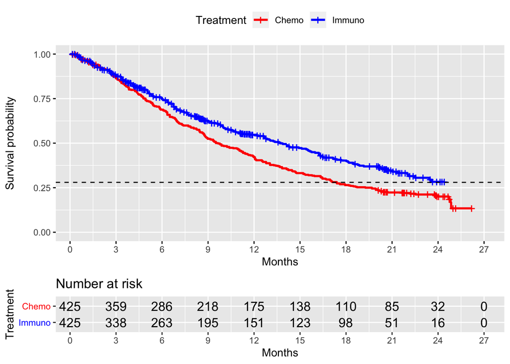

```r
## Kaplan Meier curves
fit_KM <- survfit(Surv(time,event)~tmt.arm.number,data=data_ICI_Rittmeyer)

res <- ggsurvplot(fit_KM,data=data_ICI_Rittmeyer,
           risk.table=TRUE,
           conf.int=FALSE,
           xlim=c(0.4,27),
           palette =c("red","blue"),
           xlab="Months",
           risk.table.y.text.col=T,
            break.time.by=3,
          ggtheme = theme_grey() ,
           legend.title="Treatment",
           legend.labs=c("Chemo","Immuno")
            )
res$table <- res$table + theme(axis.line = element_blank())
res$plot <- res$plot+geom_hline(yintercept=0.28,lty=2)
print(res)
```

## 2) Application of quantile regression for survival data

```r
x <- c(0.1, 0.2, 0.3, 0.4,0.5,0.6)
Rq <- crq(Surv(time,event)~tmt.arm.number,data=data_ICI_Rittmeyer,method="Pen")
result <- summary(Rq,taus=x)
result
```

```
##
## tau: [1] 0.1
##
## Coefficients:
##                Value    Lower Bd Upper Bd Std Error T Value  Pr(>|t|)
## (Intercept)     2.70243  1.64060  2.70243  0.27088   9.97646  0.00000
## tmt.arm.number -0.01844 -0.04192  1.01991  0.27088  -0.06807  0.94573
##
## tau: [1] 0.2
##
## Coefficients:
##                Value    Lower Bd Upper Bd Std Error T Value  Pr(>|t|)
## (Intercept)     4.15397  1.73010  4.69080  0.75529   5.49982  0.00000
## tmt.arm.number  0.88255 -0.08082  2.74885  0.72187   1.22259  0.22148
##
## tau: [1] 0.3
##
## Coefficients:
##                Value    Lower Bd Upper Bd Std Error T Value  Pr(>|t|)
## (Intercept)     5.86294  5.75690  6.26086  0.12857  45.60287  0.00000
## tmt.arm.number  1.02312  0.60869  1.92361  0.33544   3.05005  0.00229
##
## tau: [1] 0.4
##
## Coefficients:
##                Value   Lower Bd Upper Bd Std Error T Value Pr(>|t|)
## (Intercept)    7.80078 4.60256  9.44018  1.23411   6.32098 0.00000
## tmt.arm.number 2.12340 0.02594  5.65996  1.43728   1.47737 0.13958
##
## tau: [1] 0.5
##
## Coefficients:
##                Value    Lower Bd Upper Bd Std Error T Value  Pr(>|t|)
## (Intercept)     9.78031  7.79325 10.38313  0.66070  14.80301  0.00000
## tmt.arm.number  4.35360  2.10762  6.10739  1.02037   4.26670  0.00002
##
## tau: [1] 0.6
##
## Coefficients:
##                Value    Lower Bd Upper Bd Std Error T Value  Pr(>|t|)
## (Intercept)    12.69400 10.75741 13.63049  0.73294  17.31924  0.00000
## tmt.arm.number  5.46031  3.41729  8.15866  1.20955   4.51432  0.00001
```

```
## jack
```

```
## jack
```

```
## jack
```

```
## jack
```

```
## jack
```

```
## jack
```

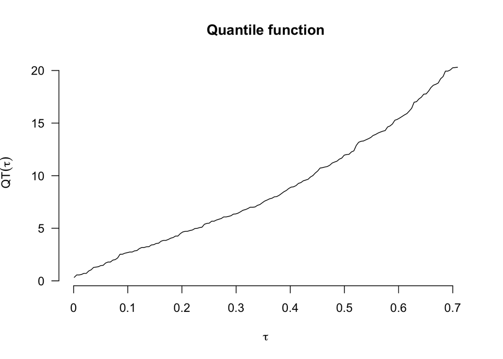

```r
# Quantile function
tau <- Rq$sol["tau",][1:160]
q<- Rq$sol["Qhat",][1:160]
plot(tau,q,type="l",xlab = expression(tau),ylab = expression(QT(tau)),
     main="Quantile function",axes=FALSE)
axis(1,at=seq(from=0,to=0.7,by=0.1),labels=seq(from=0,to=0.7,by=0.1),las=1)
axis(2,at=seq(from=0,to=20,by=5),labels=seq(from=0,to=20,by=5),las=2)
```

## 3) Resampling for confidence interval of coefficients

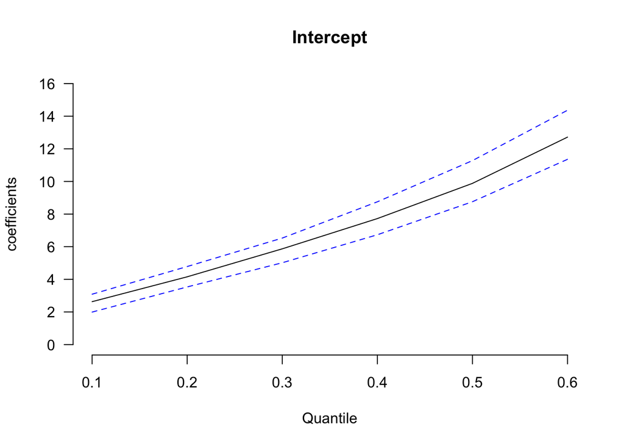

```r
############ data for bootstrapping with 1000 replications ################
load("Mat.RData")
load("Moy.RData")
load("Mat1.RData")
load("Moy1.RData")

b <- matrix(data=NA,ncol=6,nrow = 1000)
for(i in 1:6){
b[,i] <-Mat1[,i][order(Mat1[,i])]
}

inf0 <- NA
for(i in 1:6){
inf0[i] <- b[,i][25]
}
sup0 <- NA
for(i in 1:6){
  sup0[i] <- b[,i][975]
}

plot(x,Moy1,type="l",ylim=c(0,16),ylab="coefficients",xlab ="Quantile",main="Intercept",axes = FALSE)
axis(1,at=seq(from=0.1,to=0.6,by=0.1),labels=seq(from=0.1,to=0.6,by=0.1),las=1)
axis(2,at=seq(from=0,to=16,by=2),labels=seq(from=0,to=16,by=2),las=2)
lines(x,sup0,col="blue",lty=2)
lines(x,inf0,col="blue",lty=2)
```

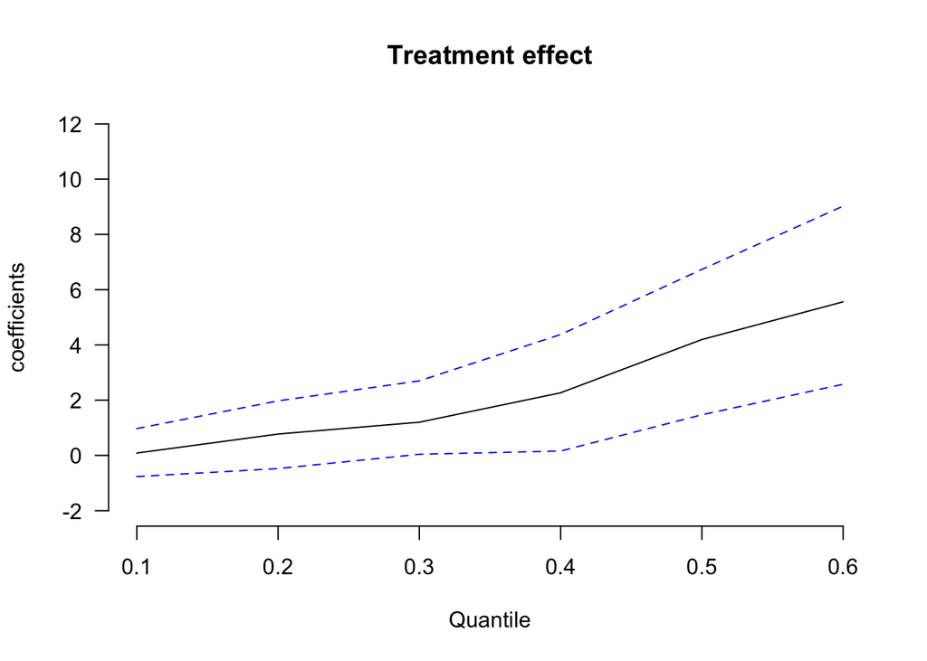

```r
## Variation of the treatment effect as function of each quantile available and confidence
# intervals
b <- matrix(data=NA,ncol=6,nrow = 1000)
for(i in 1:6){
b[,i] <-Mat[,i][order(Mat[,i])]
}

inf <- NA
for(i in 1:6){
inf[i] <- b[,i][25]
}
sup <- NA
for(i in 1:6){
  sup[i] <- b[,i][975]
}


plot(x,Moy,type="l",ylim=c(-2,12),ylab="coefficients",xlab ="Quantile",main="Treatment effect",axes = FALSE)
axis(1,at=seq(from=0.1,to=0.6,by=0.1),labels=seq(from=0.1,to=0.6,by=0.1),las=1)
axis(2,at=seq(from=-2,to=12,by=2),labels=seq(from=-2,to=12,by=2),las=2)
lines(x,sup,col="blue",lty=2)
lines(x,inf,col="blue",lty=2)
```

## 4) Benefit of treatment for each quantile

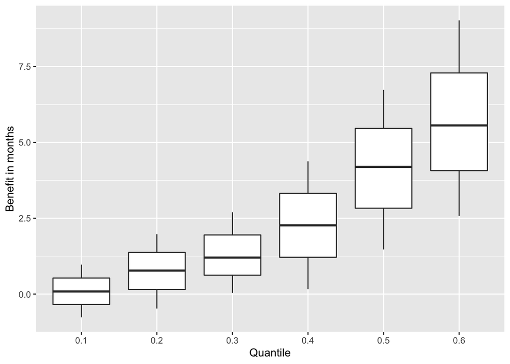

```r
datafr <- rbind.data.frame(Moy,inf,sup)
names(datafr) <- c( "0.1", "0.2", "0.3", "0.4", "0.5","0.6")
p <- ggplot(stack(datafr), aes(x=factor(ind,levels=names(datafr)), y=values))+geom_boxplot()
p+labs(x="Quantile",y="Benefit in months")
```

## 5) Visual check of the linearity assumption

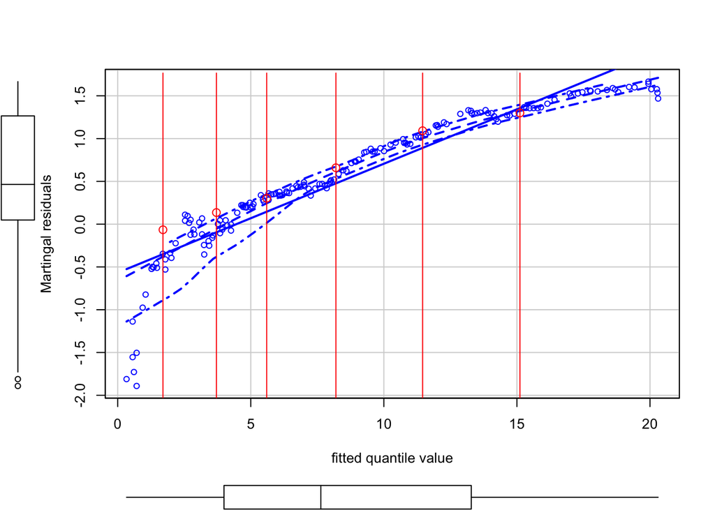

```r
x <- c(0.1,0.2,0.3,0.4,0.5,0.6)
Rq <- crq(Surv(time,event)~tmt.arm.number,data=data_ICI_Rittmeyer,method="Pen")
tau <- Rq$sol["tau",][1:160]
obs <- unname(quantile(data_ICI_Rittmeyer$time,tau))
obss <- unname(quantile(data_ICI_Rittmeyer$time,x))
q<- Rq$sol["Qhat",][1:160]
q1 <- Rq$sol["Qhat",][c(24,46,69,91,114,136)]
residu <- obs-q
residus <- obss-q1
scatterplot(q,log(abs(residu)),xlab="fitted quantile value",ylab="Martingal residuals")
points(q1,log(abs(residus)),col='red')
for(i in 1:6){
  abline(v=q1[i],col="red")
}
```

## 6) Testing equality of two groups for a given quantile using survival Kaplan Meier function

For a given quantile, we can rely on 2-samples test derived for the median survival as detailed below. Testing for equality of median was derived in (Tang et al.,Chen et al.) Once the desired quantile is identified, the methodology can be adapted. These tests, designed for detecting the difference of the median survival times, can be readily extended to compare survival quantiles.

Therefore, let’s assume that
$$\begin{align*}
\widehat{F}_1^{-1}(q)&=\inf\{t:\widehat{F}_1(t)=1-\widehat{S}_1(t)\geq q\}\\
\widehat{F}_2^{-1}(q)&=\inf\{t:\widehat{F}_2(t)=1-\widehat{S}_2(t)\geq q\} , \forall q\in [0,1]
\end{align*}$$

where $\widehat{S}_1$ and $\widehat{S}_2$ are respectively the estimated of the survival functions $S_1$ for non treated groups and $S_2$ for treated groups using the Kaplan Meier method, $widehat{F}_1$ and $\widehat{F}_2$ are right continuous, piece-wise constant estimators of $F_1$ and $F_2$ respectively.

Testing the equality of the quantile between the two groups is equivalent to testing the null hypothesis
$$\begin{align*}
H_0: F_1^{-1}(q)&=F_2^{-1}(q)\\
F_2\{F_1^{-1}(q)\}&=q
\end{align*}$$

As pointed out by Kosorok et al., $\sqrt{n}(F_2\{F_1^{-1}(q)\}-q)$ is asymptotically a zero-mean Gaussian process with variance $\sigma^2$.

We estimated the variance $\hat{\sigma}^2$ using re-sampling bootstrap method. The following statistic test
$$\begin{align*}
\frac{(\widehat{F}_2\{\widehat{F}_1^{-1}(q)\}-q)^2}{\sigma^2}
\end{align*}$$

follows a $\chi^2$-distribution with 1 degrees of freedom.

## R code

```r
quantileTest <- function(time,event,treat,q,B=1000,seed=1234){
  set.seed(seed)
  Mesdon <- cbind.data.frame(time=time,event=event,treat=treat)
  fit1 <- survfit(Surv(Mesdon$time[Mesdon$treat==0],Mesdon$event[Mesdon$treat==0])~1,conf.type ="none")
  fit2 <- survfit(Surv(Mesdon$time[Mesdon$treat==1],Mesdon$event[Mesdon$treat==1])~1,conf.type = "none")
  F1.inv <- unname(quantile(fit1, prob = q))
  F2.inv <- unname(quantile(fit2, prob = q))

  # Calculate F2(F1.inv(p))
  Qp <- function(t1,c1, t2, c2) {
    fit1 <- survfit(Surv(t1, c1)~1, conf.type = "none")
    fit2 <- survfit(Surv(t2, c2)~1, conf.type = "none")
    F1.inv <- unname(quantile(fit1, prob=q))
    if (is.na(F1.inv)) {
      warning(paste0("Error"))
      F1.inv <- max(t1)
    }
    F2  <- stepfun(fit2$time, c(0, 1-fit2$surv)) #CDF of F2
    out <- F2(F1.inv) #F2(F1.inv(p))
    return(out)
  }

  Q <- Qp(Mesdon$time[Mesdon$treat==0],Mesdon$event[Mesdon$treat==0],
          Mesdon$time[Mesdon$treat==1],Mesdon$event[Mesdon$treat==1])

  # Bootstrap
  b.est <- numeric(B)
  for (i in 1:B) {
    boot1    <- sample(1:length(Mesdon$time[Mesdon$treat==0]),replace =TRUE)
    t1.boot  <- Mesdon$time[Mesdon$treat==0][boot1]
    c1.boot  <- Mesdon$event[Mesdon$treat==0][boot1]
    boot2    <- sample(1:length(Mesdon$time[Mesdon$treat==1]),replace = TRUE)
    t2.boot  <- Mesdon$time[Mesdon$treat==1][boot2]
    c2.boot  <- Mesdon$event[Mesdon$treat==1][boot2]
    b.est[i] <- Qp(t1.boot,c1.boot,t2.boot,c2.boot)
  }

  se   <- sd(b.est)
  Z<- (Q-q)^2/se^2
  pval <- 1-pchisq(Z,1)
  return(pval)
}


## Application of the test with our data at 0.6 quantile
quantileTest(time=data_ICI_Rittmeyer$time,event=data_ICI_Rittmeyer$event,
             treat = data_ICI_Rittmeyer$tmt.arm.number,q=0.6)
```

```
## [1] 1.20207e-05
```